# A-B Test Power Analysis

2023-12-03

### Background and experimental design

- The site has `39271` visitors across 4 weeks.
- 50% are assigned to the experimental condition, the rest are the controls

### Goal

With a given conversion rate for the control group, alpha, and power level, what is the sample size required to detect that the experimental condition have a 9% higher conversion rate?

### Implementation in R

First we need to load the required `R` package. If not already installed, install.

```r
# Install if needed (delete `#` and run `install.packages("powerMediation"):
# install.packages('powerMediation')
# Load library:
library(powerMediation)
```

Setup the values from the study design and the data to insert into the R function.

In this example, let’s pretend the baseline conversion rate is 20%.

```r
sample_experimental = 39271 / 2 # sample size in experimental, given 39271 total
percent_in_experimental = sample_experimental / 39271 # above, but as a percent
BaselineConversionRate = .2 # 20%
ObjectiveConversionRate = 1.09 * BaselineConversionRate # 09.00 % higher
Alpha = .05
Power = .80
```

Run the function `SSizeLogisticBin` from the `powerMediation` package.

Here is the documentation for the function:

#### Arguments

**p1**: The baseline conversion rate.

**p2**: The converstion rate for the experimental group.

**B**: The proportion of the total sample that are in the experimental group.

**alpha**: Type I error rate (aka, significance level).

**power**: 1 - Type II error rate (aka, the power for the test).

```r
minimum_sample_size = SSizeLogisticBin(
  p1 = BaselineConversionRate, # .2 (aka, 20%)
  p2 = ObjectiveConversionRate, # .2 * 1.09 = .218 (aka, 21.8%)
  B = percent_in_experimental, # .5
  alpha = Alpha, # .05
  power = Power # .8
)

sprintf("The minimum sample size needed to detect the 9%% increase: %d", minimum_sample_size)
```

```
## [1] "The minimum sample size needed to detect the 9% increase: 16018"
```

### Example of usage with weekly data

Say you have the following data:

```r
library(tibble)
# Create an example data frame row by row:
tribble(~Week, ~TotalVisitors, ~Conversion_Rate_Control, ~Conversion_Rate_Experimental,
            1,           4000,                .200,                               .218,
            2,           8050,                .201,                               .220,
            3,          12000,                .199,                               .219,
            4,          16100,                .201,                               .217,
            5,          20050,                .200,                               .218
        )
```

```
## # A tibble: 5 × 4
##    Week TotalVisitors Conversion_Rate_Control Conversion_Rate_Experimental
##   <dbl>         <dbl>                   <dbl>                        <dbl>
## 1     1          4000                   0.2                          0.218
## 2     2          8050                   0.201                        0.22
## 3     3         12000                   0.199                        0.219
## 4     4         16100                   0.201                        0.217
## 5     5         20050                   0.2                          0.218
```

Here the `TotalVisitors` are the cumulative visitors that have appeared up until the given week. The `Conversion_Rate` is also the “running average” conversion rate so far for the visitors up until that week. (In the example, it fluctuates a little randomly just for the sake of appearing more realistic).

You can run a different function to get the power to detect if these data show significant differences in the experimental group using the `powerLigisticBin` function.

The function has the same arguments as `SSizeLogisticBin`, but this time you provide the sample size, and instead solve for power, rather than providing the (ideal) power and learning the minimum needed sample size.

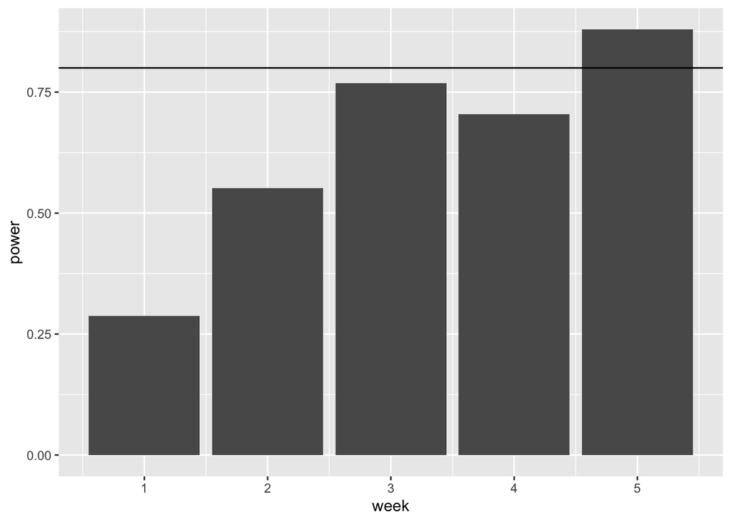

```r
# Insert the data from each week from above:
# (just collecting all in a list for later use)
power_list = list(
  week1_power = powerLogisticBin(n = 4000, p1 = .2, p2 = .218, B = .5, alpha = .05),
  week2_power = powerLogisticBin(n = 8050, p1 = .201, p2 = .22, B = .5, alpha = .05),
  week3_power = powerLogisticBin(n = 12000, p1 = .199, p2 = .219, B = .5, alpha = .05),
  week4_power = powerLogisticBin(n = 16100, p1 = .201, p2 = .217, B = .5, alpha = .05),
  week5_power = powerLogisticBin(n = 20050, p1 = .2, p2 = .218, B = .5, alpha = .05)
)

library(ggplot2)
ggplot(data = tibble(week = 1:5, power = unlist(power_list))) +
  geom_col(aes(x = week, y = power)) +
  geom_hline(aes(yintercept = .8))
```

Here you can see that upon week 5, you’ve attained the required power above .8

# Example of solving for power in the first the scenario

Bringing the two functions together, you can solve for the minimum sample size, but also learn the power (in other words, how reliable it would be to say this difference is statistically significant) in the first scenario above.

If power is over .8, then you can say with confidence what you observed is statistically significant, otherwise, no matter if the test *appears* “statistically significant” (e.g., you see an increase for the experimental group and verify it with a statistc), you wouldn’t be able to say you should be confident that that increase is going to be repeated if you were to roll out the same experiment with a new sample.

```r
# REPEATED CODE FROM ABOVE:
# minimum_sample_size = SSizeLogisticBin(
#   p1 = BaselineConversionRate, # .2 (aka, 20%)
#   p2 = ObjectiveConversionRate, # .2 * 1.09 = .218 (aka, 21.8%)
#   B = percent_in_experimental, # .5
#   alpha = Alpha, # .05
#   power = Power # .8
# )
power_of_data = powerLogisticBin(n = 39271,
                                 p1 = BaselineConversionRate,
                                 p2 = ObjectiveConversionRate,
                                 B = percent_in_experimental,
                                 alpha = .05)
sprintf("The minimum sample size needed to detect the 9%% increase: %d", minimum_sample_size)
```

```
## [1] "The minimum sample size needed to detect the 9% increase: 16018"
```

```r
sprintf("The power of to detect this actual effect with this actual sample size is: %f", power_of_data)
```

```
## [1] "The power of to detect this actual effect with this actual sample size is: 0.992390"
```